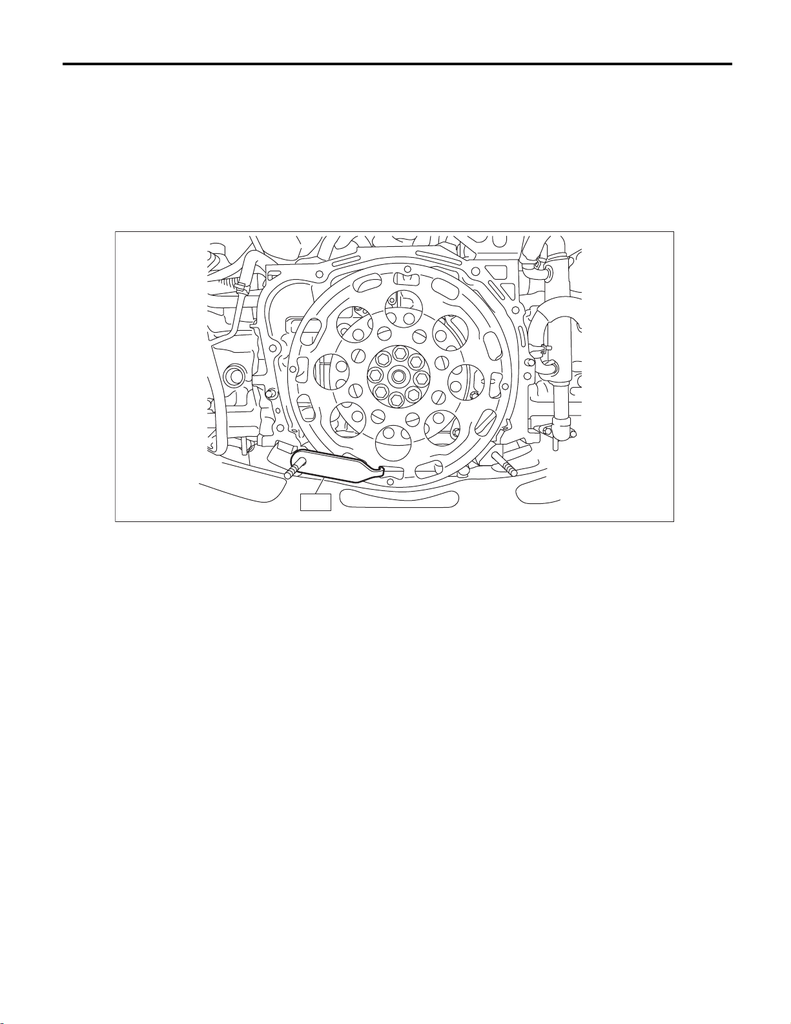

CVT(TR690)-137

Drive Plate

CONTINUOUSLY VARIABLE TRANSMISSION

25.Drive Plate

A: REMOVAL

1) Remove the transmission assembly from the vehicle. <Ref. to CVT(TR690)-56, REMOVAL, Automatic

Transmission Assembly.>

2) Set the ST.

NOTE:

Set the ST to the drive plate referring to the illustration.

ST 498497300 CRANKSHAFT STOPPER

3) Remove the drive plate and reinforcement drive plate.

ST

AT-07761

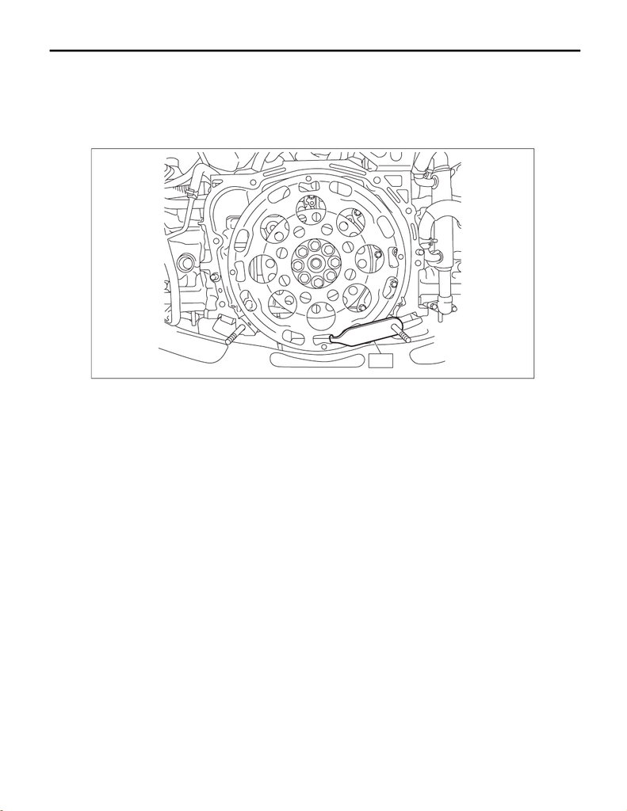

CVT(TR690)-138

Drive Plate

CONTINUOUSLY VARIABLE TRANSMISSION

B: INSTALLATION

1) Temporarily install the drive plate and reinforcement drive plate.

2) Set the ST.

NOTE:

Set the ST to the drive plate referring to the illustration.

ST 498497300 CRANKSHAFT STOPPER

3) Tighten the drive plate mounting bolt in two stages.

NOTE:

Fix the engine unit.

(1) Tighten the drive plate mounting bolt.

Tightening torque:

30 N·m (3.1 kgf-m, 22.1 ft-lb)

(2) While checking the tightening angle with the angle gauge, tighten the drive plate mounting bolts to the

specified angle.

Tightening angle:

30° — 35°

4) Install the transmission assembly to the vehicle. <Ref. to CVT(TR690)-69, INSTALLATION, Automatic

Transmission Assembly.>

AT-07762

ST